# COVID-19 Research Project

### BIOL390: Reproductible Research, Summer 2020

**Copyright (2020) Lucas Finner**

## Abstract (tl;dr)

The purpose of this research is to analyze the effects of COVID-19, specifically in Urban regions across the country. Because of the high transmission rate of the virus, it would be intruiging to study the effects a highly transmissive virus had in congested areas of the United States. This research was conducted using online resources from trusted University sources as well as highly reputable data sites. The conclusion of my analysis will compare the transmition rates COVID-19 has in urban regions compared to the average rate of tranmission within the country as a whole. By comparison, the data will show the diffrent rate this disease transmits in Urban areas.

## Introduction

COVID-19 is a viral disease that caused a global pandemic in 2020. Along with being a deadly disease to at risk people, the world has seemingly struggled to contain the virus. A main factor of this has to do with how contagious it actually is. Cities around the world have had great difficulties containing this virus, including here in the United States. The big question remains “How do you contain a virus in densely populated areas?”. There have been many conflicitng views for this question, and many cities in different states have had different answers. For this excersice the focus will be on the New York and Chicago metroplitan areas, soley because these area 2 of the 3 densest, populated areas in the USA. This research will dive into the transmittion rates of Coronavirus in urban areas, and compare it to the average. Using research analysis there will be a definitive answer for the transmission effects Coronavirus has in urban areas vs the mean.

## Hypothesis

**Urban regions in the United States are more suseptible to higher transmission rates than to the overall country**

I reached this hypothesis by reasonably thinking:

1. Diseases that are highly contagious is easier to spread when people are close together
2. The handling of the virus has been poor from the leadership levels

## Datasets used

The dataset used for this project came from the sources below:

[Harvard dataverse US Metropolitan Daily cases] (https://dataverse.harvard.edu/dataset.xhtml?persistentId=doi:10.7910/DVN/5B8YM8) [Ourworldindata] (https://ourworldindata.org/coronavirus-source-data)

## Description of analyses

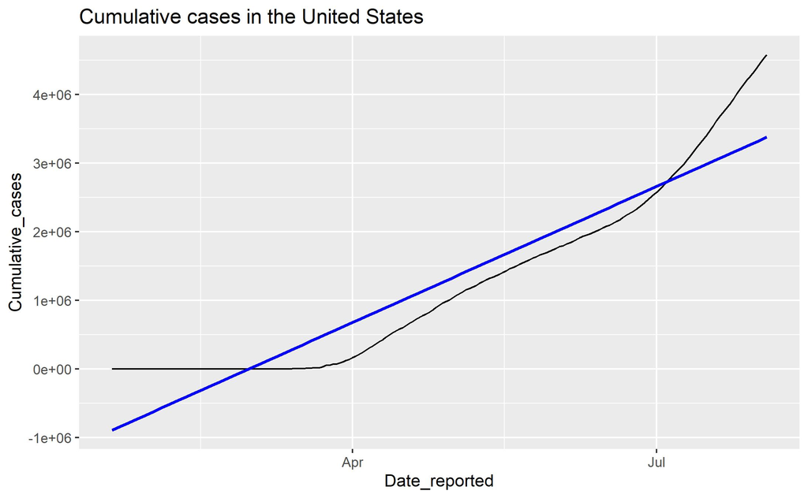

**(Graph 1)**

The tables shown indicate the average rate of infection increase is 890 for Chicago and 657 for New York. When the populations for these areas is factored in (9,533,000) and New York (20,000,000), the rate of infection per person is .00934% and .00329%, respectively.

| Metropolitan | Date | Cumulative Cases |
| --- | --- | --- |
| New York-Northern NJ-Long Is NY-NJ-PA | 7/13/20 | 496778 |
| New York-Northern NJ-Long Is NY-NJ-PA | 7/14/20 | 497578 |
| New York-Northern NJ-Long Is NY-NJ-PA | 7/15/20 | 498339 |
| New York-Northern NJ-Long Is NY-NJ-PA | 7/16/20 | 499032 |
| New York-Northern NJ-Long Is NY-NJ-PA | 7/17/20 | 499624 |
| New York-Northern NJ-Long Is NY-NJ-PA | 7/18/20 | 500281 |
| New York-Northern NJ-Long Is NY-NJ-PA | 7/19/20 | 500644 |
| New York-Northern NJ-Long Is NY-NJ-PA | 7/20/20 | 501200 |
| New York-Northern NJ-Long Is NY-NJ-PA | 7/21/20 | 501891 |
| New York-Northern NJ-Long Is NY-NJ-PA | 7/22/20 | 502838 |
| New York-Northern NJ-Long Is NY-NJ-PA | 7/23/20 | 503630 |
| New York-Northern NJ-Long Is NY-NJ-PA | 7/24/20 | 504435 |
| New York-Northern NJ-Long Is NY-NJ-PA | 7/25/20 | 505226 |
| New York-Northern NJ-Long Is NY-NJ-PA | 7/27/20 | 506636 |
| New York-Northern NJ-Long Is NY-NJ-PA | 7/28/20 | 507300 |

**(Table 1)**

| Metropolitan | Date | Cumulative Cases |
| --- | --- | --- |
| Chicago-Joliet-Naperville IL-IN-WI | 7/13/20 | 144304 |
| Chicago-Joliet-Naperville IL-IN-WI | 7/14/20 | 144893 |
| Chicago-Joliet-Naperville IL-IN-WI | 7/15/20 | 145822 |
| Chicago-Joliet-Naperville IL-IN-WI | 7/16/20 | 146804 |
| Chicago-Joliet-Naperville IL-IN-WI | 7/17/20 | 147778 |
| Chicago-Joliet-Naperville IL-IN-WI | 7/18/20 | 148743 |
| Chicago-Joliet-Naperville IL-IN-WI | 7/19/20 | 149496 |
| Chicago-Joliet-Naperville IL-IN-WI | 7/20/20 | 150318 |
| Chicago-Joliet-Naperville IL-IN-WI | 7/21/20 | 151174 |
| Chicago-Joliet-Naperville IL-IN-WI | 7/22/20 | 152425 |
| Chicago-Joliet-Naperville IL-IN-WI | 7/23/20 | 153639 |
| Chicago-Joliet-Naperville IL-IN-WI | 7/24/20 | 154744 |
| Chicago-Joliet-Naperville IL-IN-WI | 7/25/20 | 155767 |
| Chicago-Joliet-Naperville IL-IN-WI | 7/26/20 | 156903 |
| Chicago-Joliet-Naperville IL-IN-WI | 7/27/20 | 157746 |
| Chicago-Joliet-Naperville IL-IN-WI | 7/28/20 | 158549 |

**(Table 2)**

## Viewing this project

The completed project files can be accessed online at [link](https://github.com/finnerlucas/COVID-19/edit/master/README.md). The repo for this reproducible project is also publicly available at [link](https://github.com/finnerlucas/COVID-19).